# Cross-cultural validation of the ICE: Norway

Michalina Marczak

Last compiled on 23 April, 2023

## Inspection of the climate emotions data

### Multi- & uni-variate normality check

In the first step, let’s check whether the data meets the assumptions of multi- and univariate normality using Mardia’s test for multivariate skewness and kurtosis and Shapiro-Wilk test for univariate normality

```
## $mv.test
##           Test Statistic p-value Result
## 1     Skewness 64217.836       0     NO
## 2     Kurtosis   90.3598       0     NO
## 3 MV Normality      <NA>    <NA>     NO
##
## $uv.shapiro
##                  W      p-value UV.Normality
## ICE.60.no.ANG14  0.8983 0       No
## ICE.60.no.ANG13  0.8961 0       No
## ICE.60.no.ANG10  0.8834 0       No
## ICE.60.no.ANG5   0.9002 0       No
## ICE.60.no.ANG6   0.8858 0       No
## ICE.60.no.ANG8   0.8855 0       No
## ICE.60.no.ANG3   0.8918 0       No
## ICE.60.no.ANG1   0.9023 0       No
## ICE.60.no.IND7   0.8851 0       No
## ICE.60.no.DIS5   0.9068 0       No
## ICE.60.no.DIS13  0.908  0       No
## ICE.60.no.DIS10  0.8808 0       No
## ICE.60.no.IND6   0.8788 0       No
## ICE.60.no.DIS7   0.8806 0       No
## ICE.60.no.IND2   0.8863 0       No
## ICE.60.no.IND13  0.9038 0       No
## ICE.60.no.EMP12  0.8763 0       No
## ICE.60.no.EMP9   0.879  0       No
## ICE.60.no.HOPF9  0.8816 0       No
## ICE.60.no.HOPF8  0.8852 0       No
## ICE.60.no.HOPF10 0.9067 0       No
## ICE.60.no.EMP14  0.8622 0       No
## ICE.60.no.HOPF13 0.9102 0       No
## ICE.60.no.EMP7   0.8941 0       No
## ICE.60.no.POWL11 0.9056 0       No
## ICE.60.no.POWL5  0.8631 0       No
## ICE.60.no.POWL7  0.9031 0       No
## ICE.60.no.POWL4  0.9065 0       No
## ICE.60.no.POWL8  0.8869 0       No
## ICE.60.no.POWL12 0.9097 0       No
## ICE.60.no.POWL2  0.8813 0       No
## ICE.60.no.POWL13 0.9139 0       No
```

[output cut: 13 more lines]

```
## ICE.60.no.ISO12  0.8636 0       No
## ICE.60.no.ISO2   0.8647 0       No
## ICE.60.no.ISO9   0.9058 0       No
## ICE.60.no.APP10  0.8914 0       No
## ICE.60.no.HOPL7  0.8461 0       No
## ICE.60.no.HOPL1  0.8816 0       No
## ICE.60.no.APP2   0.8831 0       No
## ICE.60.no.APP7   0.8695 0       No
## ICE.60.no.HOPL5  0.8998 0       No
## ICE.60.no.HOPL11 0.9104 0       No
## ICE.60.no.APP14  0.8973 0       No
## ICE.60.no.SOR13  0.8494 0       No
## ICE.60.no.SOR6   0.8922 0       No
## ICE.60.no.SOR4   0.8837 0       No
## ICE.60.no.SOR14  0.8457 0       No
```

## Confirmatory Factor Analysis

We conduct the CFA with the Satorra-Bentler MLM because the data deviates significantly from normal distribution. Yet, there is no need to use MLR because we have complete data.

### Model specification

First, we specify the model based on the results from Marczak et al., 2022

```r
model <- 'climate_anger =~ ICE.60.no.ANG14 + ICE.60.no.ANG13 + ICE.60.no.ANG10 + ICE.60.no.ANG3
          climate_contempt =~ ICE.60.no.DIS5 + ICE.60.no.DIS7 + ICE.60.no.IND2 + ICE.60.no.IND13
          climate_enthusiasm =~ ICE.60.no.EMP12 + ICE.60.no.HOPF9 + ICE.60.no.HOPF8 + ICE.60.no.EMP7
          climate_powerlessness =~ ICE.60.no.POWL11 + ICE.60.no.POWL7 + ICE.60.no.POWL2 + ICE.60.no.POWL13
          climate_guilt =~ ICE.60.no.GUI11 + ICE.60.no.GUI6 + ICE.60.no.GUI8 + ICE.60.no.GUI12
          climate_isolation =~ ICE.60.no.ISO4 + ICE.60.no.ISO5 + ICE.60.no.ISO8 + ICE.60.no.ISO12
          climate_anxiety =~ ICE.60.no.APP7 + ICE.60.no.HOPL5 + ICE.60.no.HOPL11 + ICE.60.no.APP14
          climate_sorrow =~ ICE.60.no.SOR13 + ICE.60.no.SOR6 + ICE.60.no.SOR4 + ICE.60.no.SOR14'
```

In the next step, we fit the model with the MLM estimator

```r
model.fit <- cfa(model, data = ICE_data, estimator = "MLM")
```

### Fit indices

We inspect the standard indices for model fit

```
##          chisq.scaled         pvalue.scaled             df.scaled
##               816.532                 0.000               436.000
##            cfi.scaled            tli.scaled          rmsea.scaled
##                 0.954                 0.948                 0.042
## rmsea.ci.lower.scaled rmsea.ci.upper.scaled                  srmr
##                 0.038                 0.046                 0.050
```

Reasonably good fit is established by a model when the (in our case scaled) CFI and TLI values are close to .95 or greater, RMSEA values are close to .06 or below, and SRMR values are close to or below .08 (Hu & Bentler, 1999).

We can see that our model presents reasonably good fit.

### Model characteristics

#### Facor loadings, variances etc

```
## lavaan 0.6-12 ended normally after 82 iterations
##
##   Estimator                                         ML
##   Optimization method                           NLMINB
##   Number of model parameters                        92
##
##   Number of observations                           491
##
## Model Test User Model:
##                                               Standard      Robust
##   Test Statistic                              1012.147     816.532
##   Degrees of freedom                               436         436
##   P-value (Chi-square)                           0.000       0.000
##   Scaling correction factor                                  1.240
##     Satorra-Bentler correction
##
## Model Test Baseline Model:
##
##   Test statistic                             11039.008    8748.484
##   Degrees of freedom                               496         496
##   P-value                                        0.000       0.000
##   Scaling correction factor                                  1.262
##
## User Model versus Baseline Model:
##
##   Comparative Fit Index (CFI)                    0.945       0.954
##   Tucker-Lewis Index (TLI)                       0.938       0.948
##
##   Robust Comparative Fit Index (CFI)                         0.955
##   Robust Tucker-Lewis Index (TLI)                            0.948
##
## Loglikelihood and Information Criteria:
##
##   Loglikelihood user model (H0)             -19803.116  -19803.116
##   Loglikelihood unrestricted model (H1)     -19297.043  -19297.043
##
##   Akaike (AIC)                               39790.232   39790.232
##   Bayesian (BIC)                             40176.305   40176.305
##   Sample-size adjusted Bayesian (BIC)        39884.298   39884.298
##
```

[output cut: 206 more lines]

```
##    .ICE.60.n.HOPL5    0.496    0.039   12.717    0.000    0.496    0.353
##    .ICE.60..HOPL11    0.522    0.040   13.144    0.000    0.522    0.424
##    .ICE.60.n.APP14    0.430    0.036   11.978    0.000    0.430    0.297
##    .ICE.60.n.SOR13    0.635    0.059   10.841    0.000    0.635    0.450
##    .ICE.60.no.SOR6    0.458    0.050    9.100    0.000    0.458    0.297
##    .ICE.60.no.SOR4    0.386    0.040    9.562    0.000    0.386    0.298
##    .ICE.60.n.SOR14    0.625    0.052   11.944    0.000    0.625    0.474
##     climate_anger     1.031    0.085   12.115    0.000    1.000    1.000
##     climate_cntmpt    0.472    0.081    5.836    0.000    1.000    1.000
##     climate_nthssm    0.843    0.079   10.734    0.000    1.000    1.000
##     clmt_pwrlssnss    0.411    0.074    5.543    0.000    1.000    1.000
##     climate_guilt     1.022    0.075   13.709    0.000    1.000    1.000
##     climate_isoltn    0.577    0.075    7.702    0.000    1.000    1.000
##     climate_anxity    1.210    0.091   13.308    0.000    1.000    1.000
##     climate_sorrow    0.776    0.089    8.700    0.000    1.000    1.000
```

We observe good values here too. Importantly, all factor loadings are > .4.

#### CFA: convergent validity

Convergent validity is established when the average variance extracted (AVE) by the latent variables is greater than .5

|  | AVE |
| --- | --- |
| climate_anger | 0.711 |
| climate_contempt | 0.579 |
| climate_enthusiasm | 0.551 |
| climate_powerlessness | 0.408 |
| climate_guilt | 0.689 |
| climate_isolation | 0.591 |
| climate_anxiety | 0.668 |
| climate_sorrow | 0.620 |

Climate powerlessness has AVE < the standard cutoff .5

#### CFA: discriminant validity

Discriminant validity is established when the average correlation between a latent variable and its indicators is higher than the squared correlation between the latent variables (Fornell & Larcker, 1981).

Here are the average correlations between latent variables and their indicators:

```
##       ang.m    cont.m    enth.m    powl.m     gui.m     iso.m     anx.m
## 1 0.8842783 0.8168417 0.8149597 0.7379486 0.8743096 0.8304329 0.8644314
##       sor.m
## 1 0.8495998
```

And here is a table with squared factor correlations:

|  | climate_anger | climate_contempt | climate_enthusiasm | climate_powerlessness | climate_guilt | climate_isolation | climate_anxiety | climate_sorrow |
| --- | --- | --- | --- | --- | --- | --- | --- | --- |
| climate_anger | 1.000 | 0.417 | 0.402 | 0.457 | 0.548 | 0.339 | 0.793 | 0.850 |
| climate_contempt | 0.417 | 1.000 | 0.219 | 0.072 | 0.212 | 0.035 | 0.401 | 0.474 |
| climate_enthusiasm | 0.402 | 0.219 | 1.000 | 0.351 | 0.429 | 0.218 | 0.515 | 0.484 |
| climate_powerlessness | 0.457 | 0.072 | 0.351 | 1.000 | 0.562 | 0.325 | 0.514 | 0.466 |
| climate_guilt | 0.548 | 0.212 | 0.429 | 0.562 | 1.000 | 0.452 | 0.691 | 0.544 |
| climate_isolation | 0.339 | 0.035 | 0.218 | 0.325 | 0.452 | 1.000 | 0.457 | 0.291 |
| climate_anxiety | 0.793 | 0.401 | 0.515 | 0.514 | 0.691 | 0.457 | 1.000 | 0.833 |
| climate_sorrow | 0.850 | 0.474 | 0.484 | 0.466 | 0.544 | 0.291 | 0.833 | 1.000 |

For climate sorrow the the squared correlation between it and anger is equal to the average correlation between a latent variable and its indicators. There are no problems with other variables.

### Factor internal consistencies

#### Raykov’s rho

| clim.emotion | raykov.coefficient |
| --- | --- |
| climate_anger | 0.91 |
| climate_contempt | 0.85 |
| climate_enthusiasm | 0.83 |
| climate_powerlessness | 0.73 |
| climate_guilt | 0.9 |
| climate_isolation | 0.85 |
| climate_anxiety | 0.89 |
| climate_sorrow | 0.87 |

#### Cronbach’s alpha

|  | alpha |
| --- | --- |
| climate_anger | 0.91 |
| climate_contempt | 0.84 |
| climate_enthusiasm | 0.83 |
| climate_powerlessness | 0.72 |
| climate_guilt | 0.90 |
| climate_isolation | 0.85 |
| climate_anxiety | 0.89 |
| climate_sorrow | 0.87 |

Both coefficients indicate very good internal consistency across scales.

## Nomological span

### Recoding the reverse scored items

Some items from the scales relevant for establishing concurrent & predictive validity are reversely scored. We need to recode them.

```r
#### CPS: 5
others$CCPS.no.4 <- 8 - others$CCPS.no.4

### ULS: 3 & 6 (2 & 5 in the numeration of this dataset)
others$ULS.no.2 <- 5 - others$ULS.no.2
others$ULS.no.5 <- 5 - others$ULS.no.5
```

### Internal consistencies of other scales

Here, let’s compute Cronbach’s alpha coefficient for all the relevant scales.

|  | Climate_perceptions | Mit_policy | Loneliness | WillingnessToSacrifice |
| --- | --- | --- | --- | --- |
| raw_alpha | 0.787792116875948 | 0.873521771418476 | 0.885970814926446 | 0.943604033579507 |
| std.alpha | 0.788133334571893 | 0.878395172943132 | 0.883592081773782 | 0.944172349127838 |

### Descriptives for all the scales

|  | vars | n | mean | sd | median | trimmed | mad | min | max | range | skew | kurtosis | se |
| --- | --- | --- | --- | --- | --- | --- | --- | --- | --- | --- | --- | --- | --- |
| pro-climate perceptions | 1 | 491 | 4.876171 | 1.3995854 | 5.20 | 4.989822 | 1.48260 | 0.4 | 7 | 6.6 | -0.6463728 | -0.1104916 | 0.0631624 |
| mitigation policy support | 2 | 491 | 4.986965 | 1.4270253 | 5.20 | 5.120611 | 1.48260 | 1.0 | 7 | 6.0 | -0.7506718 | 0.2079240 | 0.0644007 |
| loneliness | 3 | 491 | 2.049389 | 0.6862662 | 2.00 | 2.009542 | 0.74130 | 1.0 | 4 | 3.0 | 0.4683637 | -0.5790583 | 0.0309708 |
| willingness to sacrifice | 4 | 491 | 5.905906 | 1.9879704 | 6.00 | 6.028499 | 1.77912 | 1.0 | 9 | 8.0 | -0.4934420 | -0.1716294 | 0.0897158 |
| climate anger | 5 | 491 | 3.314664 | 1.1054221 | 3.25 | 3.382952 | 1.11195 | 1.0 | 5 | 4.0 | -0.4313009 | -0.5822588 | 0.0498870 |
| climate contempt | 6 | 491 | 2.878310 | 1.0960658 | 3.00 | 2.860051 | 1.11195 | 1.0 | 5 | 4.0 | 0.1245479 | -0.8434825 | 0.0494648 |
| climate enthusiasm | 7 | 491 | 3.244908 | 0.8484527 | 3.25 | 3.309160 | 0.74130 | 1.0 | 5 | 4.0 | -0.6896845 | 0.3185049 | 0.0382901 |
| climate powerlessness | 8 | 491 | 3.091140 | 0.8378592 | 3.25 | 3.114504 | 0.74130 | 1.0 | 5 | 4.0 | -0.2601382 | -0.1345034 | 0.0378121 |
| climate guilt | 9 | 491 | 2.618126 | 1.0218517 | 2.75 | 2.604326 | 1.11195 | 1.0 | 5 | 4.0 | 0.0815968 | -0.7830962 | 0.0461155 |
| climate isolation | 10 | 491 | 2.360489 | 0.9368515 | 2.25 | 2.300254 | 1.11195 | 1.0 | 5 | 4.0 | 0.5014615 | -0.1845568 | 0.0422795 |
| climate anxiety | 11 | 491 | 3.095214 | 1.0342218 | 3.25 | 3.152036 | 1.11195 | 1.0 | 5 | 4.0 | -0.4453573 | -0.5753040 | 0.0466738 |
| climate sorrow | 12 | 491 | 3.558045 | 1.0027724 | 3.75 | 3.649491 | 1.11195 | 1.0 | 5 | 4.0 | -0.7582294 | 0.0820503 | 0.0452545 |

### Distribution of the variables

We will investigate the distribution using the Shapiro-Wilk test.

```
## $`pro-climate perceptions`
##
##  Shapiro-Wilk normality test
##
## data:  X[[i]]
## W = 0.95608, p-value = 0.00000000006445
##
##
## $`mitigation policy support`
##
##  Shapiro-Wilk normality test
##
## data:  X[[i]]
## W = 0.94481, p-value = 0.000000000001504
##
##
## $loneliness
##
##  Shapiro-Wilk normality test
##
## data:  X[[i]]
## W = 0.96019, p-value = 0.0000000002959
##
##
## $` willingness to sacrifice`
##
##  Shapiro-Wilk normality test
##
## data:  X[[i]]
## W = 0.96424, p-value = 0.000000001472
##
##
## $`climate anger`
##
##  Shapiro-Wilk normality test
##
## data:  X[[i]]
## W = 0.95387, p-value = 0.00000000002943
##
##
```

[output cut: 39 more lines]

```
##
## $`climate anxiety`
##
##  Shapiro-Wilk normality test
##
## data:  X[[i]]
## W = 0.9557, p-value = 0.00000000005616
##
##
## $`climate sorrow`
##
##  Shapiro-Wilk normality test
##
## data:  X[[i]]
## W = 0.93827, p-value = 0.0000000000002141
```

For all variables p < .05 so we can say that most of our variables deviate from normal distribution

### Correlational analysis

As the data deviates from the normal distribution and because it is ordinal anyways, let’s use Spearman correlation coefficients.

|  | climate concern | gender | age | residence area | education | perceived SES | pro-climate perceptions | mitigation policy support | loneliness | willingness to sacrifice | climate anger | climate contempt | climate enthusiasm | climate powerlessness | climate guilt | climate isolation | climate anxiety | climate sorrow |
| --- | --- | --- | --- | --- | --- | --- | --- | --- | --- | --- | --- | --- | --- | --- | --- | --- | --- | --- |
| climate concern |  |  |  |  |  |  |  |  |  |  |  |  |  |  |  |  |  |  |
| gender | -0.08 |  |  |  |  |  |  |  |  |  |  |  |  |  |  |  |  |  |
| age | -0.14** | 0.19*** |  |  |  |  |  |  |  |  |  |  |  |  |  |  |  |  |
| residence area | -0.15*** | 0.02 | 0.27*** |  |  |  |  |  |  |  |  |  |  |  |  |  |  |  |
| education | 0.15*** | -0.07 | 0.06 | -0.10* |  |  |  |  |  |  |  |  |  |  |  |  |  |  |
| perceived SES | 0.03 | 0.07 | 0.02 | 0.03 | 0.03 |  |  |  |  |  |  |  |  |  |  |  |  |  |
| pro-climate perceptions | 0.73*** | -0.09 | -0.10* | -0.15*** | 0.15*** | 0.02 |  |  |  |  |  |  |  |  |  |  |  |  |
| mitigation policy support | 0.68*** | -0.07 | -0.15** | -0.19*** | 0.18*** | -0.02 | 0.72*** |  |  |  |  |  |  |  |  |  |  |  |
| loneliness | 0.12** | -0.11* | -0.24*** | -0.07 | -0.14** | 0.02 | 0.02 | 0.05 |  |  |  |  |  |  |  |  |  |  |
| willingness to sacrifice | 0.65*** | -0.04 | -0.01 | -0.09* | 0.12** | 0.08 | 0.59*** | 0.62*** | -0.04 |  |  |  |  |  |  |  |  |  |
| climate anger | 0.75*** | -0.08 | -0.17*** | -0.15*** | 0.09 | 0.04 | 0.66*** | 0.66*** | 0.15*** | 0.59*** |  |  |  |  |  |  |  |  |
| climate contempt | -0.57*** | 0.09 | 0.04 | 0.03 | -0.06 | -0.02 | -0.69*** | -0.61*** | 0.00 | -0.48*** | -0.53*** |  |  |  |  |  |  |  |
| climate enthusiasm | 0.47*** | -0.12** | -0.14** | -0.13** | 0.02 | -0.02 | 0.38*** | 0.50*** | 0.01 | 0.45*** | 0.45*** | -0.30*** |  |  |  |  |  |  |
| climate powerlessness | 0.41*** | -0.12* | -0.30*** | -0.17*** | -0.02 | -0.02 | 0.30*** | 0.33*** | 0.35*** | 0.20*** | 0.50*** | -0.14** | 0.35*** |  |  |  |  |  |
| climate guilt | 0.64*** | -0.12** | -0.30*** | -0.16*** | 0.01 | 0.00 | 0.48*** | 0.49*** | 0.24*** | 0.48*** | 0.63*** | -0.39*** | 0.51*** | 0.56*** |  |  |  |  |
| climate isolation | 0.44*** | 0.01 | -0.18*** | -0.10* | -0.02 | 0.03 | 0.26*** | 0.31*** | 0.26*** | 0.35*** | 0.48*** | -0.12** | 0.32*** | 0.39*** | 0.54*** |  |  |  |
| climate anxiety | 0.78*** | -0.11* | -0.18*** | -0.15*** | 0.04 | 0.01 | 0.64*** | 0.59*** | 0.16*** | 0.58*** | 0.77*** | -0.49*** | 0.52*** | 0.51*** | 0.73*** | 0.57*** |  |  |
| climate sorrow | 0.74*** | -0.15*** | -0.16*** | -0.12** | 0.07 | 0.01 | 0.69*** | 0.64*** | 0.09* | 0.59*** | 0.80*** | -0.56*** | 0.49*** | 0.45*** | 0.60*** | 0.40*** | 0.75*** |  |

Note: N = 489; Climate concern: 0 - “Not at all concerned”, 1 - “Not very concerned”, 2 - “Somewhat concerned”, 3 - “Very concerned”, 4 - “Extremely concerned”; Gender: 0 - Female, 1 - Male (the option “other” (n = 1) was not included in this correlational analysis); Residence area: 0 - “A big city”, 1 - “The suburbs or outskirts of a big city”, 2 - “A town or a small city”, 3 - “A country village”, 4 - “A farm or home in the countryside”; Education: 0 - “Primary education”, 1 - “Secondary education or vocational training”, 3 - “University/college degree” (the option “other” (n = 1) was not included in this correlational analysis); Perceived SES: 0 - “Finding it very difficult on present income”, 1 - ““Finding it difficult on present income”, 2 - “Coping on present income”, 3 - “Living comfortably on present income”.

#### Heatmap

A hierarchically clustered heatmap summarising the correlational analysis; the clustering was performed based on the complete-linkage method.

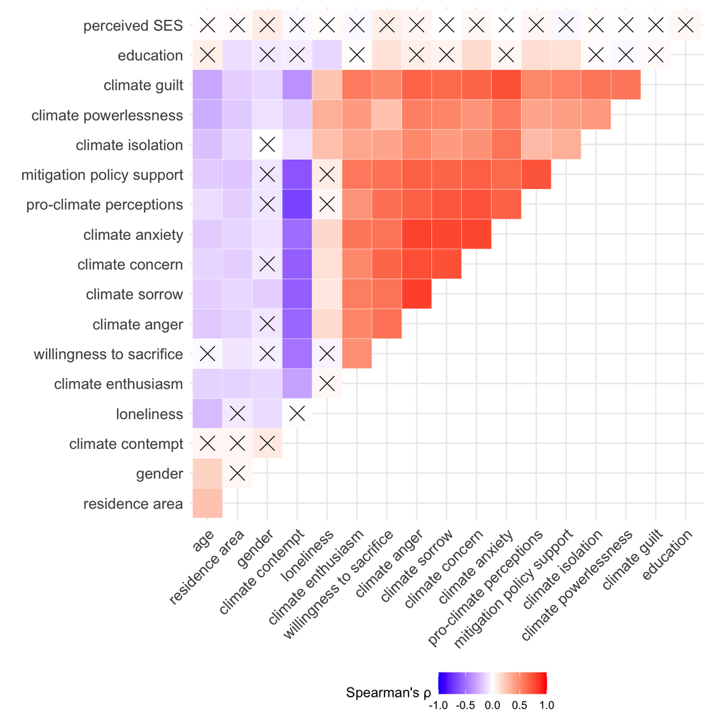

## Note

This html output presents the general logic of the analysis along with some results not outlined in the main body of the manuscript. Please note that the full R code for the data cleaning and data analysis is available in the supplementary materials on the accompanying OSF website.